# 04 In-Class Assignment: Linear Algebra and Python

[figure not shown]

Image from: Mathbyfives @[YouTube](https://www.youtube.com/watch?v=fSCz7jH_vHI)

### Agenda for today's class (80 minutes)

1. (20 minutes) Pre Class Review
2. (20 minutes) Solving Systems of Linear Equations
3. (20 minutes) Underdetermined Systems
4. (20 minutes) Practice Curve Fitting Example

## 1. Pre Class Review

```python
# Here are some libraries you may need to use
%matplotlib inline
import matplotlib.pylab as plt
import numpy as np
import sympy as sym
import math
sym.init_printing()
```

Discuss Ax=b format as it relates to augmented matrix.

## 2. Solving Systems of Linear Equations

Remember the following set of equations from the mass weight example:

[figure not shown]

$$40A + 15B = 100$$$$25B = 50 + 50A$$

As you know, the above system of equations can be written as an Augmented Matrix in the following form:

$$ \left[ \begin{matrix} 40 & 15 \\ -50 & 25 \end{matrix} \, \middle\vert \, \begin{matrix} 100 \\ 50 \end{matrix} \right] $$

✅ **QUESTION:** Split apart the augmented matrix ($ \left[ \begin{matrix} A \end{matrix} \, \middle\vert \, \begin{matrix} b \end{matrix} \right] $) into its left size ($2 \times 2$) matrix $A$ and its right ($2x1$) matrix $b$. Define the matrices $A$ and $b$ as `numpy` matrices:

```python
#Put your code here
A = np.matrix('40 15; -50 25')
A
b = np.matrix('100; 50')
b
```

```
matrix([[100],
        [ 50]])
```

```python
from answercheck import checkanswer

checkanswer.matrix(A,'f5bfd7c52824d5ac580d0ce1ab98fe68');
```

````
CheckWarning: passed matrix is int64 and not <class 'numpy.float64'>...
    Trying to convert to float using ```A = A.astype(float)```.

Testing [[ 40.  15.]
 [-50.  25.]]
Answer seems to be correct
````

```python
from answercheck import checkanswer

checkanswer.matrix(b,'c760cd470439f5db82bb165edf4dc3f8');
```

````
CheckWarning: passed matrix is int64 and not <class 'numpy.float64'>...
    Trying to convert to float using ```A = A.astype(float)```.

Testing [[100.]
 [ 50.]]
Answer seems to be correct
````

✅ **QUESTION:** solve the above system of equations using the `np.linalg.solve` function and store the value in a vector named x:

```python
# Put your code to the above question here
x = np.linalg.solve(A,b)
```

```python
from answercheck import checkanswer

checkanswer.vector(x,'fc02fe6d0577c4452ee70252e1e17654');
```

````
CheckWarning: numpy.matrix is row vector...
    Trying to convert to a column vector using ```A = A.T```.

Testing [[1. 4.]]
Answer seems to be correct
````

### Sympy RREF function

The Python `sympy` library has a "reduced row echelon form" (rref) function that runs a much more efficient version of the Gauss-Jordan elimination. To use the rref function you must first convert your matrix into a `sympy.Matrix` and then run the function. For example, let's do this for the following matrix $B$:

```python
B =np.matrix([[ 50, 13, 30 ], [100, 26, 60 ],  [20.5, 25, 650]])
sym.Matrix(B).rref()
```

$\displaystyle \left( \left[\begin{matrix}1 & 0 & -7.82918149466192\\0 & 1 & 32.4199288256228\\0 & 0 & 0\end{matrix}\right], \ \left( 0, \ 1\right)\right)$

This function outputs two values (a matrix and a tuple). For the purposes of this class we only care about the matrix. I generally use the following syntax when using `rref()`

```python
sym.Matrix(B).rref()[0]
```

$\displaystyle \left[\begin{matrix}1 & 0 & -7.82918149466192\\0 & 1 & 32.4199288256228\\0 & 0 & 0\end{matrix}\right]$

✅**QUESTION**: Although we do not use it often in this course, what does the second output of the `rref` mean (i.e. what does `(0,1)` mean? *hint*: read the documentation for `rref`.

## 3. Underdetermined Systems

Sometimes we have systems of linear equations where we have more unknowns than equations, in this case we call the system "underdetermined." These types of systems can have an infinite number of solutions. i.e., we can not find an unique $x$ such that $Ax=b$. In this case, we can find a set of equations that represent all of the solutions that solve the problem by using Gauss Jordan and the Reduced Row Echelon form. Let's consider the following example:

$$\begin{bmatrix}5&-2&2 & 1 \\ 4 & -3 &4 &2 \\ 4& -6 &7 & 4\end{bmatrix}\begin{bmatrix}x_1\\x_2\\x_3\\x_4\end{bmatrix}=\begin{bmatrix}1\\2\\3\end{bmatrix}$$

✅ **QUESTION** Define an augmented matrix $M$ that represents the above system of equations:

```python
#Put your code here
M =  np.matrix('5, -2, 2, 1, 1; 4, -3, 4, 2, 2; 4, -6, 7, 4, 3')

#sym.Matrix(M).rref()
```

✅ **QUESTION** What is the Reduced Row Echelon form for A?

```python
from answercheck import checkanswer

checkanswer.matrix(M,'efb9b2da0e44984a18f595d7892980e2');
```

````
CheckWarning: passed matrix is int64 and not <class 'numpy.float64'>...
    Trying to convert to float using ```A = A.astype(float)```.

Testing [[ 5. -2.  2.  1.  1.]
 [ 4. -3.  4.  2.  2.]
 [ 4. -6.  7.  4.  3.]]
Answer seems to be correct
````

```python
# Put your answer to the above question here
RREF = sym.Matrix(M).rref()[0]
```

```python
from answercheck import checkanswer

checkanswer.matrix(RREF,'f1fa8baac1df4c378db20cff9e91ca5b');
```

````
CheckWarning: passed variable is <class 'sympy.matrices.dense.MutableDenseMatrix'> and not a numpy.matrix...
    Trying to convert to a array matrix using ```A = np.matrix(A)```.


CheckWarning: passed matrix is object and not <class 'numpy.float64'>...
    Trying to convert to float using ```A = A.astype(float)```.


CheckWarning: Matrix contains negative values for zero...
    Converting to positive values of zero using  ```A[A==-0] = 0```.

Testing [[ 1.       0.       0.      -0.06667  0.06667]
 [ 0.       1.       0.      -0.4      0.4    ]
 [ 0.       0.       1.       0.26667  0.73333]]
Answer seems to be correct
````

Notice how the above RREF form of matrix A is different from what we have seen in the past. In this case not all of our values for $x$ are unique. When we write down a solution to this problem by defining the variables by one or more of the undefined variables. For example, here we can see that $x_4$ is undefined. So we say $x_4 = x_4$, i.e. $x_4$ can be any number we want. Then we can define $x_3$ in terms of $x_4$. In this case $x_3 = \frac{11}{15} - \frac{4}{15}x_4$. The entire solution can be written out as follows:

$$ \begin{align*} x_1 &= \frac{1}{15} + \frac{1}{15}x_4 \\ x_2 &= \frac{2}{5} + \frac{2}{5}x_4 \\ x_3 &= \frac{11}{15} - \frac{4}{15}x_4 \\ x_4 &= x_4 \end{align*} $$

✅ **DO THIS** Review the above answer and make sure you understand how we get this answer from the Reduced Row Echelon form from above.

Sometimes, in an effort to make the solution more clear, we introduce new variables (typically, $r,s,t$) and substitute them in for our undefined variables so the solution would look like the following:

$$ \begin{align*} x_1 &= \frac{1}{15} + \frac{1}{15}r \\ x_2 &= \frac{2}{5} + \frac{2}{5}r \\ x_3 &= \frac{11}{15} - \frac{4}{15}r \\ x_4 &= r \end{align*} $$

We can find a particular solution to the above problem by inputing any number for $r$. For example, set r equal to zero and create a vector for all of the $x$ values.

$$ \begin{align*} x_1 &= \frac{1}{15}\\ x_2 &= \frac{2}{5}\\ x_3 &= \frac{11}{15} \\ x_4 &= 0 \end{align*} $$

```python
##here is the same basic math in python

r = 0
x = np.matrix([1/15+1/15*r, 2/5+2/5*r, 11/15-4/15*r, r]).T
x
```

```
matrix([[0.06666667],
        [0.4       ],
        [0.73333333],
        [0.        ]])
```

## 4. Practice Curve Fitting Example

Consider the following polynomial with constant scalars $a$, $b$, and $c$, that falls on the $xy$-plane:

$$f(x) = ax^2 + bx + c$$

✅ **QUESTION:** Is this function linear? Why or why not?

No the function is not linear. The exponents imply nonlinear. Also it is not in the form f(x) = mx + b.

Assume that we do not know the values of $a$, $b$ and $c$, but we do know that the points (1,2), (-1,12), and (2,3) are on the graph of the above polynomial. We can substitute the known points into the equation above. For example, using point (1,2) we get the following equation:

$$2 = a1^2 + b1 + c$$$$\text{or}$$$$2 = a + b + c$$

✅ **QUESTION:** Generate two more equations by substituting points (-1,12) and (2,3) into the above equation:

$$12 = a(-1)^2 + b(-1) + c$$$$\text{or}$$$$12 = a - b + c$$$$3 = a(2)^2 + b(2) + c$$$$\text{or}$$$$3 = 4a + 2b + c$$

✅ **QUESTION:** If we did this right, we should have three equations and three unknowns ($a,b,c$). Note also that these equations are linear (how did that happen?). Transform this system of equations into two matrices $A$ and $b$ like we did above.

```python
#Put your answer to the above question here.
A = np.matrix('1 1 1;1 -1 1;4 2 1')
b = np.matrix('2;12;3')
```

```python
from answercheck import checkanswer

checkanswer.matrix(A,'1896041ded9eebf1cba7e04f32dd1069');
```

````
CheckWarning: passed matrix is int64 and not <class 'numpy.float64'>...
    Trying to convert to float using ```A = A.astype(float)```.

Testing [[ 1.  1.  1.]
 [ 1. -1.  1.]
 [ 4.  2.  1.]]
Answer seems to be correct
````

```python
from answercheck import checkanswer

checkanswer.matrix(b,'01e594bb535b4e2f5a04758ff567f918');
```

````
CheckWarning: passed matrix is int64 and not <class 'numpy.float64'>...
    Trying to convert to float using ```A = A.astype(float)```.

Testing [[ 2.]
 [12.]
 [ 3.]]
Answer seems to be correct
````

✅ **QUESTION** Write the code to solve for $x$ (i.e., ($a,b,c$)) using `numpy`.

```python
#Put your answer to the above question here.

x = np.linalg.solve(A,b)
```

```python
from answercheck import checkanswer

checkanswer.vector(x,'1dab22f81c2c156e6adca8ea7ee35dd7');
```

````
CheckWarning: numpy.matrix is row vector...
    Trying to convert to a column vector using ```A = A.T```.

Testing [[ 2. -5.  5.]]
Answer seems to be correct
````

✅ **QUESTION** Given the value of your `x` matrix derived in the previous question, what are the values for $a$, $b$, and $c$?

```python
#Put your answer to the above question here.
a = 2
b = -5
c = 5
```

Assuming the above is correct, the following code will print your 2nd order polynomial and plot the original points:

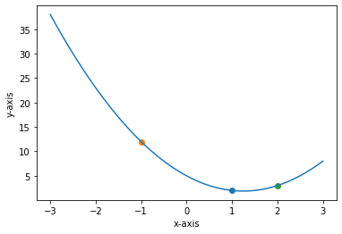

```python
x = np.linspace(-3,3)
y = a*x**2 + b*x + c

#plot the function. (Transpose is needed to make the data line up).
plt.plot(x,y.transpose())

#Plot the original points
plt.scatter(1, 2)
plt.scatter(-1, 12)
plt.scatter(2, 3)
plt.xlabel('x-axis')
plt.ylabel('y-axis')
```

✅ **QUESTION** The following program is intended to take four points as inputs ($p1, p2, p3, p4 \in R^2$) and calculate the coefficients $a$, $b$, $c$, and $d$ so that the graph of $f(x) = ax^3 + bx^2 + cx + d$ passes smoothly through the points. Test the function with the following points (1,2), (-1,6), (2,3), (3,2) as inputs and print the values for $a$, $b$, $c$, and $d$.

```python
def fitPoly3(p1,p2,p3,p4):
    A = np.matrix([[p1[0]**3, p1[0]**2, p1[0], 1],
                   [p2[0]**3, p2[0]**2, p2[0], 1],
                   [p3[0]**3, p3[0]**2, p3[0], 1],
                   [p4[0]**3, p4[0]**2, p4[0], 1]])

    b = np.matrix([p1[1],p2[1],p3[1],p4[1]]).T

    X = np.linalg.solve(A, b)
    a = X[0]
    b = X[1]
    c = X[2]
    d = X[3]
    #Try to put your figure generation code here for the next question
    #####Start your code here #####
    points = np.array([p1[0],p2[0],p3[0],p4[0]])
    x = np.linspace(points.min()-1, points.max()+1)
    y = a*x**3 + b*x**2 + c*x + d

    plt.plot(x,y.transpose())

    plt.scatter(p1[0],p1[1])
    plt.scatter(p2[0],p2[1])
    plt.scatter(p3[0],p3[1])
    plt.scatter(p4[0],p4[1])

    #####End of your code here#####
    return (a,b,c,d)
```

```
(matrix([[-0.5]]), matrix([[2.]]), matrix([[-1.5]]), matrix([[2.]]))
```

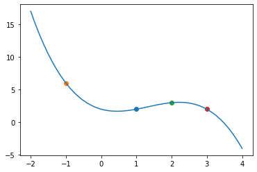

```python
#put your answer to the above question here
fitPoly3((1,2), (-1,6), (2,3), (3,2))
```

✅ **QUESTION** Modify the above `fitpoly3` function to also generate a figure of the input points and the resulting polynomial in range `x=(-3,3)`.

```python
# Put the answer to the above question above or copy and paste the above function and modify it in this cell.
def fitPoly3(p1,p2,p3,p4):
    A = np.matrix([[p1[0]**3, p1[0]**2, p1[0], 1],
                   [p2[0]**3, p2[0]**2, p2[0], 1],
                   [p3[0]**3, p3[0]**2, p3[0], 1],
                   [p4[0]**3, p4[0]**2, p4[0], 1]])

    b = np.matrix([p1[1],p2[1],p3[1],p4[1]]).T

    X = np.linalg.solve(A, b)
    a = X[0]
    b = X[1]
    c = X[2]
    d = X[3]
    #Try to put your figure generation code here for the next question
    #####Start your code here #####
    points = np.array([p1[0],p2[0],p3[0],p4[0]])
    x = np.linspace(points.min()-2, points.max())
    y = a*x**3 + b*x**2 + c*x + d

    plt.plot(x,y.transpose())

    plt.scatter(p1[0],p1[1])
    plt.scatter(p2[0],p2[1])
    plt.scatter(p3[0],p3[1])
    plt.scatter(p4[0],p4[1])


    #####End of your code here#####
    return (a,b,c,d)
```

```
(matrix([[-0.5]]), matrix([[2.]]), matrix([[-1.5]]), matrix([[2.]]))
```

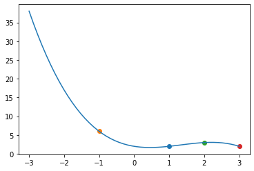

```python
fitPoly3((1,2), (-1,6), (2,3), (3,2))
```

✅ **QUESTION** Give any four $R^2$ input points to `fitPoly3`, is there always a unique solution? Explain your answer.

There is not a unique solution or a solution always when using any four points in the fitPOly3 function. For example if two points were to be the same as variables we entered then there would be no solution.

Written by Dr. Dirk Colbry, Michigan State University  
This work is licensed under a [Creative Commons Attribution-NonCommercial 4.0 International License](http://creativecommons.org/licenses/by-nc/4.0/).

### Congratulations, we're done!